# Leaflet Maps

## Accessing Administrative Boundaries

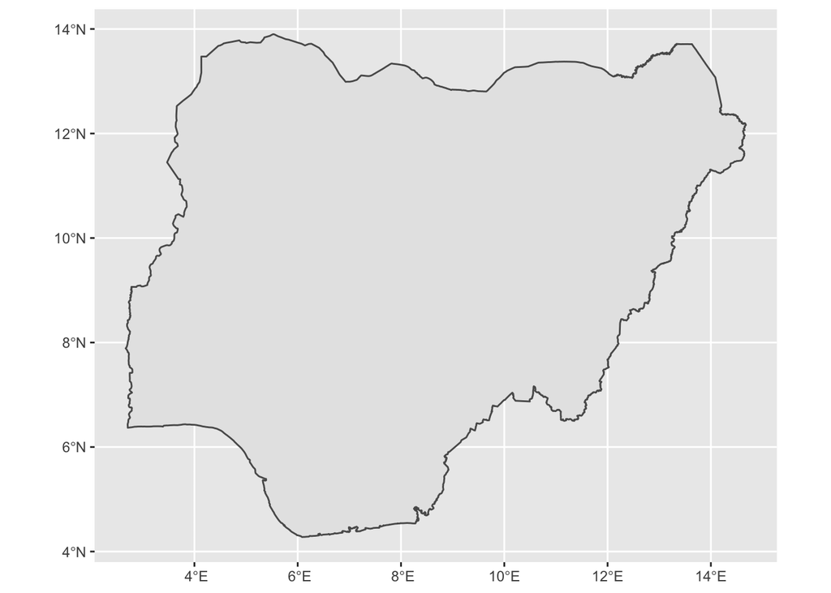

```r
# One country
nigeria <- geoboundaries(country = "Nigeria") #<<

ggplot(data = nigeria) +
  geom_sf()
```

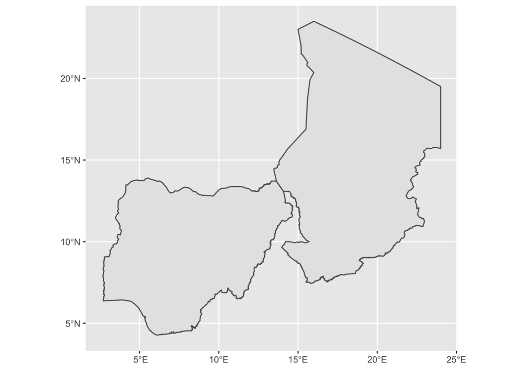

```r
# Two countries
nigeria_chad <- geoboundaries(country = c("Nigeria", "Chad")) #<<

ggplot(data = nigeria_chad) +
  geom_sf()
```

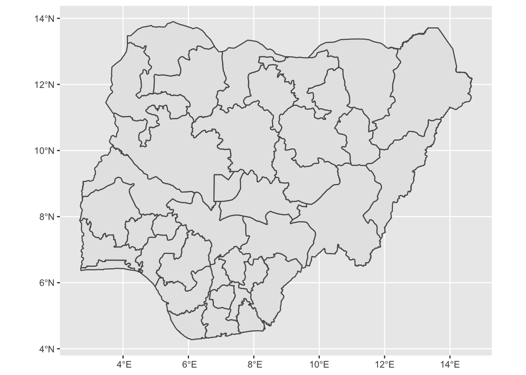

```r
# Admin Level 1
nigeria <- geoboundaries(country = "Nigeria",
                         adm_lvl = "adm1") #<<

ggplot(data = nigeria) +
  geom_sf()
```

Find out more administrative boundaries and other open data sources tutorials at rspatialdata.github.io

```r
nigeria %>%
  kableExtra::kable()
```

| shapeName | shapeISO | shapeID | shapeGroup | shapeType | geometry |
| --- | --- | --- | --- | --- | --- |
| Abia | NG-AB | NGA-ADM1-1590546715-B1 | NGA | ADM1 | MULTIPOLYGON (((7.547192 5…. |
| Adamawa | NG-AD | NGA-ADM1-1590546715-B2 | NGA | ADM1 | MULTIPOLYGON (((13.71303 10… |
| Akwa lbom | NG-AK | NGA-ADM1-1590546715-B3 | NGA | ADM1 | MULTIPOLYGON (((8.332865 4…. |
| Anambra | NG-AN | NGA-ADM1-1590546715-B4 | NGA | ADM1 | MULTIPOLYGON (((7.339063 6…. |
| Bauchi | NG-BA | NGA-ADM1-1590546715-B5 | NGA | ADM1 | MULTIPOLYGON (((11.00732 11… |
| Bayelsa | NG-BY | NGA-ADM1-1590546715-B6 | NGA | ADM1 | MULTIPOLYGON (((5.746892 4…. |
| Benue | NG-BE | NGA-ADM1-1590546715-B7 | NGA | ADM1 | MULTIPOLYGON (((9.179126 7…. |
| Borno | NG-BO | NGA-ADM1-1590546715-B8 | NGA | ADM1 | MULTIPOLYGON (((13.71303 10… |
| Cross River | NG-CR | NGA-ADM1-1590546715-B9 | NGA | ADM1 | MULTIPOLYGON (((8.305132 4…. |
| Delta | NG-DE | NGA-ADM1-1590546715-B10 | NGA | ADM1 | MULTIPOLYGON (((6.668921 6…. |
| Ebonyi | NG-EB | NGA-ADM1-1590546715-B11 | NGA | ADM1 | MULTIPOLYGON (((8.294515 6…. |
| Edo | NG-ED | NGA-ADM1-1590546715-B12 | NGA | ADM1 | MULTIPOLYGON (((6.664701 6…. |
| Ekiti | NG-EK | NGA-ADM1-1590546715-B13 | NGA | ADM1 | MULTIPOLYGON (((5.773028 7…. |
| Enugu | NG-EN | NGA-ADM1-1590546715-B14 | NGA | ADM1 | MULTIPOLYGON (((7.807141 6…. |
| Federal Capital Territory | NG-FC | NGA-ADM1-1590546715-B15 | NGA | ADM1 | MULTIPOLYGON (((7.730055 9…. |
| Gombe | NG-GO | NGA-ADM1-1590546715-B16 | NGA | ADM1 | MULTIPOLYGON (((11.64015 10… |
| Imo | NG-IM | NGA-ADM1-1590546715-B17 | NGA | ADM1 | MULTIPOLYGON (((7.263917 5…. |
| Jigawa | NG-JI | NGA-ADM1-1590546715-B18 | NGA | ADM1 | MULTIPOLYGON (((10.59405 12… |
| Kaduna | NG-KD | NGA-ADM1-1590546715-B19 | NGA | ADM1 | MULTIPOLYGON (((8.779404 10… |
| Kano | NG-KN | NGA-ADM1-1590546715-B20 | NGA | ADM1 | MULTIPOLYGON (((9.193549 11… |
| Katsina | NG-KT | NGA-ADM1-1590546715-B21 | NGA | ADM1 | MULTIPOLYGON (((9.045213 12… |
| Kebbi | NG-KE | NGA-ADM1-1590546715-B22 | NGA | ADM1 | MULTIPOLYGON (((4.942946 11… |
| Kogi | NG-KO | NGA-ADM1-1590546715-B23 | NGA | ADM1 | MULTIPOLYGON (((6.82789 8.4… |
| Kwara | NG-KW | NGA-ADM1-1590546715-B24 | NGA | ADM1 | MULTIPOLYGON (((6.208536 8…. |
| Lagos | NG-LA | NGA-ADM1-1590546715-B25 | NGA | ADM1 | MULTIPOLYGON (((4.350838 6…. |
| Nasarawa | NG-NA | NGA-ADM1-1590546715-B26 | NGA | ADM1 | MULTIPOLYGON (((8.657807 9…. |
| Niger | NG-NI | NGA-ADM1-1590546715-B27 | NGA | ADM1 | MULTIPOLYGON (((5.960175 11… |
| Ogun | NG-OG | NGA-ADM1-1590546715-B28 | NGA | ADM1 | MULTIPOLYGON (((4.088356 7…. |
| Ondo | NG-ON | NGA-ADM1-1590546715-B29 | NGA | ADM1 | MULTIPOLYGON (((6.004126 7…. |
| Osun | NG-OS | NGA-ADM1-1590546715-B30 | NGA | ADM1 | MULTIPOLYGON (((5.057633 8…. |
| Oyo | NG-OY | NGA-ADM1-1590546715-B31 | NGA | ADM1 | MULTIPOLYGON (((4.568998 8…. |
| Plateau | NG-PL | NGA-ADM1-1590546715-B32 | NGA | ADM1 | MULTIPOLYGON (((8.823522 10… |
| Rivers | NG-RI | NGA-ADM1-1590546715-B33 | NGA | ADM1 | MULTIPOLYGON (((7.263917 5…. |
| Sokoto | NG-SO | NGA-ADM1-1590546715-B34 | NGA | ADM1 | MULTIPOLYGON (((6.791399 13… |
| Taraba | NG-TA | NGA-ADM1-1590546715-B35 | NGA | ADM1 | MULTIPOLYGON (((10.97489 9…. |
| Yobe | NG-YO | NGA-ADM1-1590546715-B36 | NGA | ADM1 | MULTIPOLYGON (((12.39355 13… |
| Zamfara | NG-ZA | NGA-ADM1-1590546715-B37 | NGA | ADM1 | MULTIPOLYGON (((7.032052 12… |

### Joining spreadsheet data to spatial data

- Let’s say we have population data we want to match.

```r
# Two countries
nigeria_pop <- read_csv(file = "data/nga_admpop_adm1_2020.csv") #<<

head(nigeria_pop)
```

```
## # A tibble: 6 × 58
##   ADM0_NAME ADM0_PCODE ADM1_NAME ADM1_PCODE   F_TL   M_TL   T_TL F_00_04 F_05_09
##   <chr>     <chr>      <chr>     <chr>       <dbl>  <dbl>  <dbl>   <dbl>   <dbl>
## 1 NIGERIA   NG         ABIA      NG001      1.94e6 1.94e6 3.88e6  210483  215867
## 2 NIGERIA   NG         ADAMAWA   NG002      2.17e6 2.23e6 4.40e6  372760  320576
## 3 NIGERIA   NG         AKWA IBOM NG003      2.79e6 2.88e6 5.67e6  326260  342223
## 4 NIGERIA   NG         ANAMBRA   NG004      2.93e6 3.00e6 5.94e6  319470  334304
## 5 NIGERIA   NG         BAUCHI    NG005      3.27e6 3.42e6 6.69e6  639299  509011
## 6 NIGERIA   NG         BAYELSA   NG006      1.24e6 1.30e6 2.54e6  150454  157800
## # … with 49 more variables: F_10_14 <dbl>, F_15_19 <dbl>, F_20_24 <dbl>,
## #   F_25_29 <dbl>, F_30_34 <dbl>, F_35_39 <dbl>, F_40_44 <dbl>, F_45_49 <dbl>,
## #   F_50_54 <dbl>, F_55_59 <dbl>, F_60_64 <dbl>, F_65_69 <dbl>, F_70_74 <dbl>,
## #   F_75_79 <dbl>, F_80Plus <dbl>, M_00_04 <dbl>, M_05_09 <dbl>, M_10_14 <dbl>,
## #   M_15_19 <dbl>, M_20_24 <dbl>, M_25_29 <dbl>, M_30_34 <dbl>, M_35_39 <dbl>,
## #   M_40_44 <dbl>, M_45_49 <dbl>, M_50_54 <dbl>, M_55_59 <dbl>, M_60_64 <dbl>,
## #   M_65_69 <dbl>, M_70_74 <dbl>, M_75_79 <dbl>, M_80Plus <dbl>, …
```

In what column do we find spatial information we can use to match this data to the other dataset?

- We can match the data based on the names of the administrative boundaries.

```r
# Joining Nigeria spatial data to the population data by the admin name columns

nigeria_pop <- nigeria_pop %>%
  mutate(ADM1_NAME = str_to_title(ADM1_NAME, locale = "en"))

# how well do they match up?
anti_join(x = nigeria,
          y = nigeria_pop,
          by = c("shapeName" = "ADM1_NAME"))
```

```
## Simple feature collection with 1 feature and 5 fields
## Geometry type: MULTIPOLYGON
## Dimension:     XY
## Bounding box:  xmin: 7.460275 ymin: 4.478005 xmax: 8.34163 ymax: 5.519353
## Geodetic CRS:  WGS 84
##   shapeName shapeISO                shapeID shapeGroup shapeType
## 1 Akwa lbom    NG-AK NGA-ADM1-1590546715-B3        NGA      ADM1
##                         geometry
## 1 MULTIPOLYGON (((8.332865 4....
```

Often one of the trickiest part is to get the spelling of regions to match up. We can check where mismatches occur with an `anti_join`. The NA here is from Akwa Lbom and Akwa lbom.

- We can fix mismatches using `case_when`

```r
# Joining Nigeria spatial data to the population data by the administrative data column

nigeria_pop <- nigeria_pop %>%
  mutate(ADM1_NAME = str_to_title(ADM1_NAME, locale = "en"),
         ADM1_NAME_SC = case_when(ADM1_NAME == "Akwa Ibom" ~ "Akwa lbom",
                               TRUE ~ ADM1_NAME))

nigeria_df <- left_join(x = nigeria,
                        y = nigeria_pop,
                        by = c("shapeName" = "ADM1_NAME_SC"))
```

We can use `case_when` to change the name to match.

- Now we can create our map

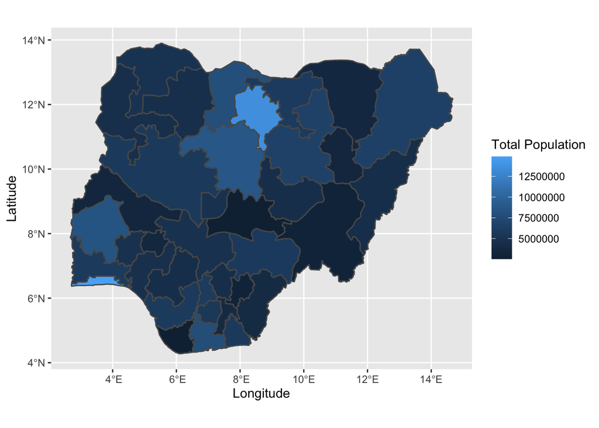

```r
ggplot(data = nigeria_df) +
  geom_sf(aes(fill = T_TL)) +
  labs(x = "Longitude",
       y = "Latitude",
       fill = "Total Population")
```

## Coordinate reference system

- Every location on earth is specified by a longitude and latitude.
- The Coordinate Reference system (CRS) determines how the data will be projected onto a map.
- We can check the CRS using `st_crs`:

```r
st_crs(nc)
```

```
## Coordinate Reference System:
##   User input: NAD27
##   wkt:
## GEOGCRS["NAD27",
##     DATUM["North American Datum 1927",
##         ELLIPSOID["Clarke 1866",6378206.4,294.978698213898,
##             LENGTHUNIT["metre",1]]],
##     PRIMEM["Greenwich",0,
##         ANGLEUNIT["degree",0.0174532925199433]],
##     CS[ellipsoidal,2],
##         AXIS["latitude",north,
##             ORDER[1],
##             ANGLEUNIT["degree",0.0174532925199433]],
##         AXIS["longitude",east,
##             ORDER[2],
##             ANGLEUNIT["degree",0.0174532925199433]],
##     ID["EPSG",4267]]
```

- The CRS is specified in the attributes `epsg` and `proj4string`.

```r
### Fill in the blank to check the nigeria data set

st_crs(____)
```

## Transforming coordinate reference system

- You can transform a coordinate reference system using the `st_transform()`.
- But what is a sensible coordinate reference system to assign?
- Well, a good place to start is with the one that leaflet uses for plotting the world: EPSG 4326.

```r
nc <- st_transform(nc, "+init=epsg:4326")

st_crs(nc)
```

```
## Coordinate Reference System:
##   User input: +init=epsg:4326
##   wkt:
## GEOGCRS["unknown",
##     DATUM["World Geodetic System 1984",
##         ELLIPSOID["WGS 84",6378137,298.257223563,
##             LENGTHUNIT["metre",1]],
##         ID["EPSG",6326]],
##     PRIMEM["Greenwich",0,
##         ANGLEUNIT["degree",0.0174532925199433],
##         ID["EPSG",8901]],
##     CS[ellipsoidal,2],
##         AXIS["longitude",east,
##             ORDER[1],
##             ANGLEUNIT["degree",0.0174532925199433,
##                 ID["EPSG",9122]]],
##         AXIS["latitude",north,
##             ORDER[2],
##             ANGLEUNIT["degree",0.0174532925199433,
##                 ID["EPSG",9122]]]]
```

```r
## Fill in the blanks for the nigeria dataset
nigeria_df <- st_transform(nigeria_df, "+init=epsg:4326")

______(nc)
```

# Our first leaflet map

- Every plot starts with `leaflet()`

```r
leaflet(data = nc)
```

[interactive chart not shown]

- Layers are added using `%>%`

```r
leaflet(data = nc) %>%
  addTiles() #<<
```

[interactive chart not shown]

- N.B. Layers are added with `%>%` in `leaflet` and `+` in `ggplot`. `%>%` also is used in the `tidyverse` packages.
- We can set the view using `setView()`

```r
leaflet(data = nc) %>%
  addTiles() %>%
  setView(lng = -80, #<<
          lat = 34.5, #<<
          zoom = 5) #<<
```

[interactive chart not shown]

- Add different background map using addProviderTiles

```r
leaflet(data = nc) %>%
  addProviderTiles(providers$Esri.OceanBasemap) %>%
  setView(lng = -80,
          lat = 34.5,
          zoom = 5)
```

[interactive chart not shown]

- N.B. The different provider tiles come with different licensing.
- Add polygons using `addPolygons()`

```r
leaflet(data = nc) %>%
  addProviderTiles(providers$Stamen.Terrain) %>%
  setView(lng = -80,
          lat = 34.5,
          zoom = 5) %>%
  addPolygons() #<<
```

[interactive chart not shown]

- Fill in the blanks to create a leaflet map with the Nigeria data. What longitude and latitude do you want to set the view with?

```r
leaflet(data = ) %>%
  addProviderTiles(providers$Stamen.Terrain) %>%
  setView(lng = _____,
          lat = _____,
          zoom = 5) %>%
  addPolygons() #<<
```

## Creating a colour palette

- What type of data are we showing?
- Who is our audience?
- Tools
  - [ColorBrewer2.org](https://colorbrewer2.org/#type=sequential&scheme=BuGn&n=3)
  - [Color Picker](https://www.colorcodepicker.com/)

## Creating a colour palette

- `RColorBrewer` includes **sequential** colour palettes (e.g. number of people).

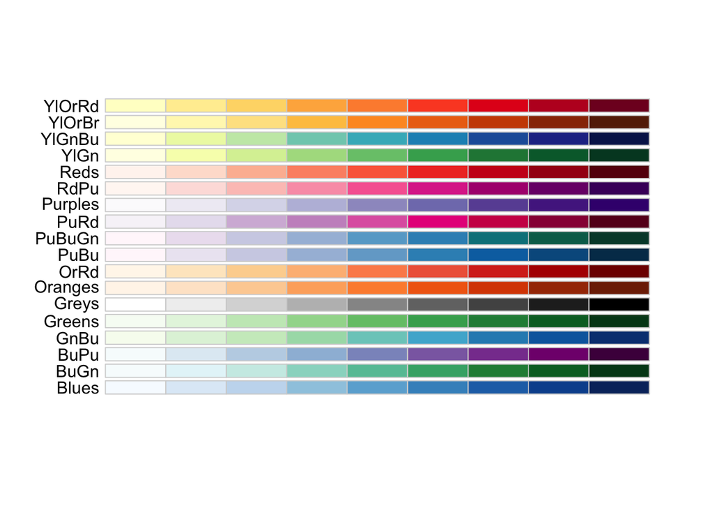

```r
display.brewer.all(type = "seq")
```

## Creating a colour palette

- `RColorBrewer` includes **diverging** colour palettes (e.g. to show distinct categories).

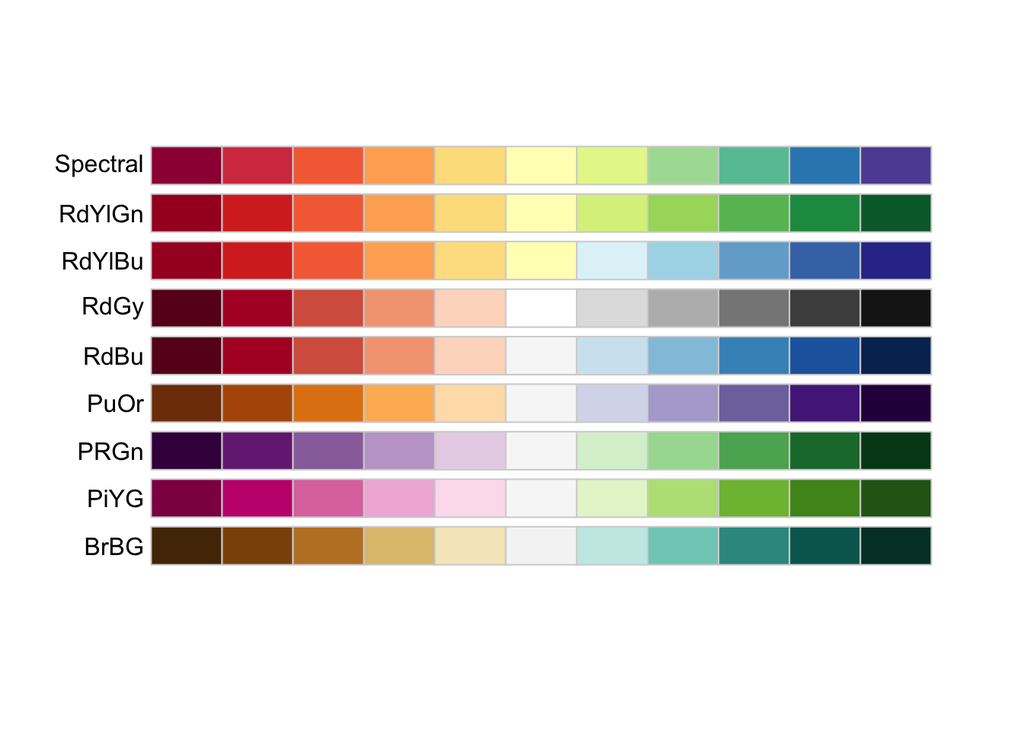

```r
display.brewer.all(type = "div")
```

- First we will define the colour palette and bins for the plot.

```r
summary(nc$births1974)
```

```
##    Min. 1st Qu.  Median    Mean 3rd Qu.    Max.
##     248    1077    2180    3300    3936   21588
```

```r
summary(nc$births1979)
```

```
##    Min. 1st Qu.  Median    Mean 3rd Qu.    Max.
##     319    1336    2636    4224    4889   30757
```

```r
bins <- seq(0, 35000, 5000)
```

- Then we can define the colours for the palette:

```r
pal74 <- colorBin("OrRd", domain = nc$births1974, bins = bins)

pal79 <- colorBin("OrRd", domain = nc$births1979, bins = bins)
```

- What might make sense as bins for showing our Nigeria population?

```r
summary(nigeria_df$TL)

bins <- seq(from = ___, to = ____, by = ____)


pal <- colorBin("OrRd", domain = ________, bins = bins)
```

- Customising `addPolygons()`

```r
leaflet(data = nc) %>%
  addProviderTiles(providers$Stamen.Terrain) %>%
  setView(lng = -80,
          lat = 34.5,
          zoom = 6) %>%
  addPolygons(
    fillColor = ~pal74(nc$births1974),
    fillOpacity = 0.7, #<<
    color = "white", #<<
    opacity = 1, #<<
    weight = 2 #<<
  )
```

[interactive chart not shown]

```r
# Try further customizing your Nigeria plot

leaflet(data = ) %>%
  addProviderTiles(providers$Stamen.Terrain) %>%
  setView(lng = _____,
          lat = _____,
          zoom = 5) %>%
  addPolygons(
    fillColor = ~pal(_______),
    fillOpacity = 0.7, #<<
    color = "white", #<<
    opacity = 1, #<<
    weight = 2 #<<
  ) #<<
```

- Customising `addPolygons()`

```r
leaflet(data = nc) %>%
  addProviderTiles(providers$Stamen.Terrain) %>%
  setView(lng = -80,
          lat = 34.5,
          zoom = 6) %>%
  addPolygons(
    fillColor = ~pal74(nc$births1974), #<<
    fillOpacity = 1, #<<
    color = "blue", #<<
    opacity = 0.7, #<<
    weight = 1 #<<
  )
```

[interactive chart not shown]

# What can you customise in addPolygons()

```r
?addPolygons()
```

- `color:` stroke color
- `weight:` stroke width in pixels
- `opacity:` stroke opacity
- `fillColor:` fill color
- `fillOpacity:` fill opacity
- `highlightOptions:` Options for highlighting the shape on mouse over.
- Let’s assign our plot to an object.

```r
m1 <- leaflet(data = nc) %>% #<<
  addProviderTiles(providers$Stamen.Terrain) %>%
  setView(lng = -80,
          lat = 34.5,
          zoom = 6)

m1 %>%
  addPolygons(
    fillColor = ~pal74(nc$births1974),
    fillOpacity = 0.7,
    opacity = 1,
    color = "white",
    weight = 2)
```

[interactive chart not shown]

- Let’s add some `highlightOptions`

```r
m1 %>%
  addPolygons(
      fillColor = ~pal74(nc$births1974),
      fillOpacity = 0.7,
      color = "white",
      opacity = 1,
      weight = 2,
    highlight = highlightOptions( #<<
        weight = 3, #<<
        color = "blue", #<<
        fillOpacity = 1, #<<
        bringToFront = TRUE)) #<<
```

[interactive chart not shown]

## Let’s add some labels!

`sprintf`: returns a character vector containing a formatted combination of text and variable values.

```r
labels <- sprintf("<strong>%s</strong><br/>%g births",
                  nc$county, nc$births1974) %>% lapply(htmltools::HTML)

head(labels, 1)
```

```
## [[1]]
## <strong>Ashe</strong><br/>1091 births
```

html - markup language for the web * `<strong>` = bold; `<br/>` = new line

PHP - Hypertext Preprocessor * `%s` = place holder for a character string; `%g` = general format place holder for a number

```r
(m1 <- m1 %>%
  addPolygons(data = nc,
      fillColor = ~pal74(nc$births1974),
      fillOpacity = 0.7,
      color = "white",
      opacity = 1,
      weight = 2,
      highlight = highlightOptions(
        weight = 3,
        color = "blue",
        fillOpacity = 1,
        bringToFront = TRUE),
      label = labels)) #<<
```

[interactive chart not shown]

- Let’s add a legend

```r
m1 <- m1 %>%
  addLegend( #<<
    position = "bottomright", #<<
    pal = pal74, #<<
    values = ~nc$births1974, #<<
    title = "Births by county in 1974", #<<
    opacity = 1) #<<

m1
```

[interactive chart not shown]

## Let’s create a second map

- Let’s create a second map of births in 1979.
- First we’ll need to create a new set of labels

```r
labels79 <- sprintf(
  "<strong>%s</strong><br/>%g births",
  nc$county, nc$births1979
) %>% lapply(htmltools::HTML)
```

## Let’s create a second map

```r
m2 <- leaflet(data = nc) %>%
  addProviderTiles(providers$Stamen.Terrain) %>%
  setView(lng = -80, lat = 34.5, zoom = 6) %>%
  addPolygons(
      fillColor = ~pal79(nc$births1979),
      fillOpacity = 0.7,
      color = "white",
      opacity = 1,
      weight = 2,
      highlight = highlightOptions(
        weight = 3,
        color = "blue",
        fillOpacity = 1,
        bringToFront = TRUE),
      label = labels79)
```

```r
(m2 <- m2 %>%
  addLegend(
    position = "bottomright",
    pal = pal79,
    values = ~nc$births1979,
    title = "Births by country in 1979",
    opacity = 1))
```

[interactive chart not shown]

## Placing two maps side by side

```r
leafsync::sync(m1, m2, ncol = 2, sync = "all")
```

[interactive chart not shown]

# Leaflet maps with points

```r
work <- data.frame(
  "location" = c("Valparaíso, Chile",
                 "Curitiba, Brasil",
                 "Sable Island, Nova Scotia",
                 "Greifswald, Germany",
                 "Arusha, Tanzania",
                 "Kigali, Rwanda",
                 "Kingston, Jamaica",
                 "Asunción, Paraguay",
                 "East Kilbride, Scotland"),
  "institute" = c("Instituto de Fomento Pesquero",
                  "Universidade Federal do Paraná",
                  "Dalhousie University",
                  "Friedrich Loeffler Institut",
                  "Nelson Mandela African Institute of Science and Technology",
                  "National Institute of Statistics Rwanda",
                  "Caribbean National Statistical Offices",
                  "El Ministerio de Salud Pública y Bienestar Social y el Ministerio de Educación y Ciencias - Paraguay",
                  "Foreign Commonwealth Development Office"),
  "work" = c("Chilean Pink Cusk Eel",
             "Fox rabies",
             "Grey seals",
             "Fox rabies",
             "Teaching",
             "Teaching",
             "Teaching",
             "Teaching",
             "Teaching"),
  "lat" = c(-33.0472,
            -25.4290,
            43.9337,
            54.0865,
            -3.3995,
            -1.9415,
            18.0179,
            -25.2637,
            55.760869),
  "lon" = c(-71.6127,
            -49.2671,
            -59.9149,
            13.3923,
            36.7968,
            30.0574,
            -76.8099,
            -57.5759,
            -4.22407),
  "icon" = c("fish",
             "disease",
             "gps",
             "disease",
             "training",
             "training",
             "training",
             "training",
             "training"))
```

```r
work %>%
  kbl() %>%
  kable_paper("hover")
```

| location | institute | work | lat | lon | icon |
| --- | --- | --- | --- | --- | --- |
| Valparaíso, Chile | Instituto de Fomento Pesquero | Chilean Pink Cusk Eel | -33.04720 | -71.61270 | fish |
| Curitiba, Brasil | Universidade Federal do Paraná | Fox rabies | -25.42900 | -49.26710 | disease |
| Sable Island, Nova Scotia | Dalhousie University | Grey seals | 43.93370 | -59.91490 | gps |
| Greifswald, Germany | Friedrich Loeffler Institut | Fox rabies | 54.08650 | 13.39230 | disease |
| Arusha, Tanzania | Nelson Mandela African Institute of Science and Technology | Teaching | -3.39950 | 36.79680 | training |
| Kigali, Rwanda | National Institute of Statistics Rwanda | Teaching | -1.94150 | 30.05740 | training |
| Kingston, Jamaica | Caribbean National Statistical Offices | Teaching | 18.01790 | -76.80990 | training |
| Asunción, Paraguay | El Ministerio de Salud Pública y Bienestar Social y el Ministerio de Educación y Ciencias - Paraguay | Teaching | -25.26370 | -57.57590 | training |
| East Kilbride, Scotland | Foreign Commonwealth Development Office | Teaching | 55.76087 | -4.22407 | training |

```r
leaflet(work) %>%
      addProviderTiles(providers$Stamen.Watercolor) %>%
      addProviderTiles(providers$Stamen.TerrainLabels) %>%
      addCircleMarkers(~lon, ~lat)
```

[interactive chart not shown]

- **Your Turn*** What else can you change about addCircleMarkers? Hint: Type `??addControl` Try adding: `clusterOptions = markerClusterOptions()` to your map.
- Add labels

```r
labels <- sprintf(
  "<strong>%s</strong>",
  work$institute) %>% lapply(htmltools::HTML)
```

```r
(work_map <- leaflet(work) %>%
                addProviderTiles(providers$Stamen.Watercolor) %>%
                addProviderTiles(providers$Stamen.TerrainLabels) %>%
                addCircleMarkers(~lon, ~lat, popup = ~labels))
```

[interactive chart not shown]